# R Stats Tuto

## The point plot:

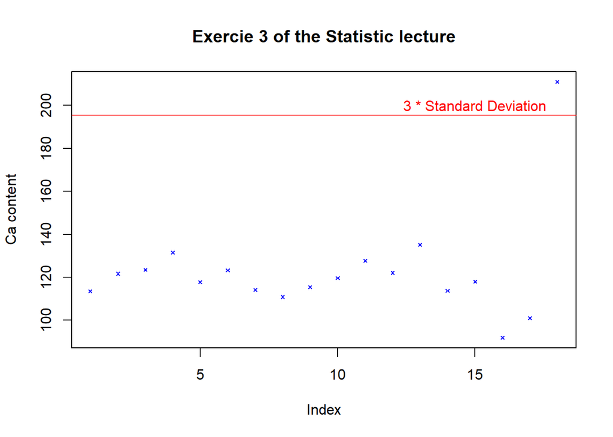

```r
plot(Ca,
  type = "p", # type de tracé: points ("p"), lignes ("l"), les deux ("b" ou "o"),
  col = "blue", # couleur, tapez `colours()` pour la liste complète
  pch = 4, # type de symboles, un chiffre entre 0 et 25, tapez `?points`
  cex = 0.5, # taille des symboles
  lty = 3, # type de lignes, un chiffre entre 1 et 6
  lwd = 1.2, # taille de lignes
  ylab = "Ca content", # titre pour l'axe des y
  main="Exercie 3 of the Statistic lecture")
abline(h=mean(Ca)+3*sd(Ca), col="red") # Add a line on the graphic
text(15,200, "3 * Standard Deviation", col="red") # Add a text on the graphic
```

`abline` & `text` functions can add a line and a text respectively in the graphic.

With `ggplot2` use `geom.point()`:

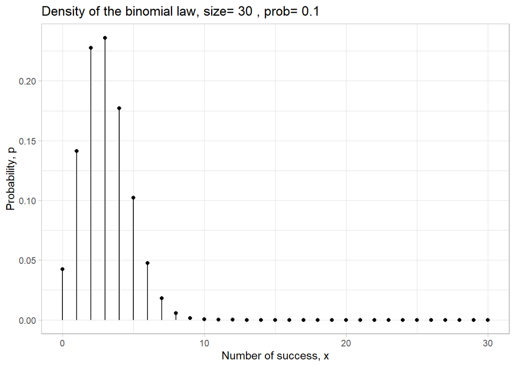

```r
# Example of data frame for a binomial law
df_binom<-data.frame(x=c(0:n),p=dbinom(x=c(0:n),size=n,prob=p))
# Genaration of a graph
ggplot(data=df_binom)+
  aes(x=x,y=p)+
  geom_point()+
  geom_segment(aes(x=x,y=0,xend=x,yend=p))+
  theme_light()+
  xlab("Number of success, x")+
  ylab("Probability, p")+
  labs(title=paste("Density of the binomial law, size=",n,", prob=",p))
```

## The Barplot

Basic R code for to generate a barplot of a Poison law:

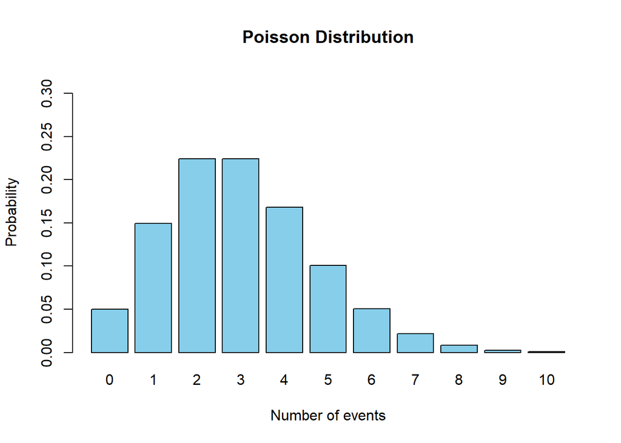

```r
# Poisson distribution parameter
lambda <- 3  # Lambda parameter

# Generate values from the Poisson distribution
x <- c(0:10)  # Possible values (adjust as needed)
probas <- dpois(x, lambda = lambda)  # PDF

# Create the barplot
barplot(probas, names.arg = x, col = "skyblue", main = "Poisson Distribution",
        xlab = "Number of events", ylab = "Probability", ylim = c(0, max(probas) + 0.1))
```

With `ggplot2` use `geom.bar()`:

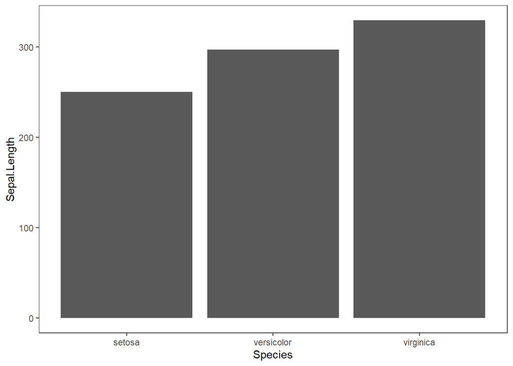

```r
ggplot(iris, aes(x = Species, y = Sepal.Length))+
  geom_bar(stat = "identity")+
  theme_test()
```

It is possible to have multigroup in the barplot. It’s just needed to add the parameter `fill = group2` in the `aes()`. By default the group are stacked. To have the barplot side by side, add `position=position_dodge()` in the `geom_bar` parameter.

More complicate, the case of 2 continue variables y. It is not possible at this step with `geom_bar` function, which allow only one x for one y. To solve this issue, it’s needed to reorganized the data to transform a table with y columns to a table with only two columns. This transformation can be done with the function `gather(data, key, value, columns_to_gather)` of the library `tidyr`.

- **data** ==> data frame, example iris
- **key** ==> name of the group
- **value** ==> name of the y axis
- **columns_to_gather** ==> y variables of the original data frame that it needed to be merged, separate by `,`

```r
# Formatage of the data thanks to the library tidyr
library(tidyr)
reformat <- gather(iris, key = "Part_flower", value = "Length", Sepal.Length, Petal.Length)
head(reformat)
```

|  | Sepal.Width | Petal.Width | Species | Part_flower | Length |
| --- | --- | --- | --- | --- | --- |
| 1 | 3.5 | 0.2 | setosa | Sepal.Length | 5.1 |
| 2 | 3.0 | 0.2 | setosa | Sepal.Length | 4.9 |
| 3 | 3.2 | 0.2 | setosa | Sepal.Length | 4.7 |
| 4 | 3.1 | 0.2 | setosa | Sepal.Length | 4.6 |
| 5 | 3.6 | 0.2 | setosa | Sepal.Length | 5.0 |
| 6 | 3.9 | 0.4 | setosa | Sepal.Length | 5.4 |

```r
# Work on the mean and Standard deviation
reformat.summary <- reformat %>%
  group_by(Part_flower, Species) %>%
  summarise( sd = sd(Length), len = mean(Length))
reformat.summary
```

| Part_flower | Species | sd | len |
| --- | --- | --- | --- |
| Petal.Length | setosa | 0.1736640 | 1.462 |
| Petal.Length | versicolor | 0.4699110 | 4.260 |
| Petal.Length | virginica | 0.5518947 | 5.552 |
| Sepal.Length | setosa | 0.3524897 | 5.006 |
| Sepal.Length | versicolor | 0.5161711 | 5.936 |
| Sepal.Length | virginica | 0.6358796 | 6.588 |

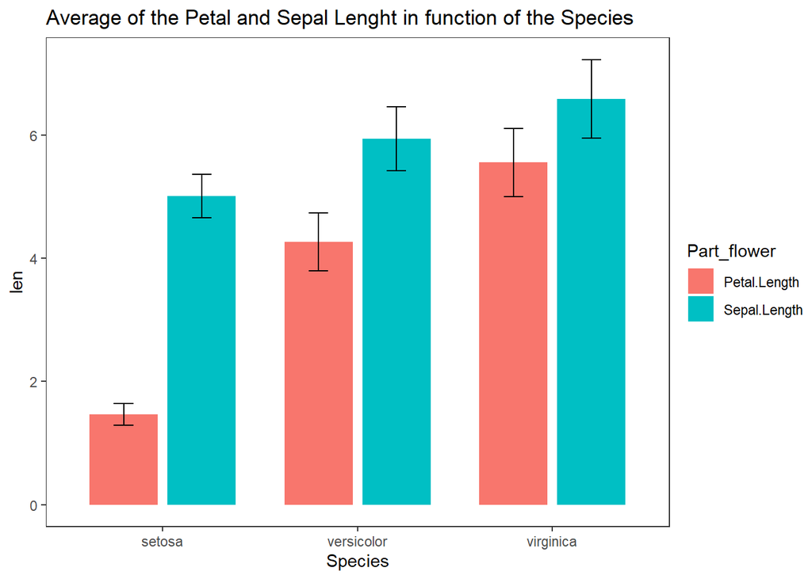

```r
# Plot
ggplot(reformat.summary, aes(x = Species, y = len, fill=Part_flower))+
  geom_bar(stat = "identity", position=position_dodge(0.8), width = 0.7)+
  geom_errorbar(
    aes(ymin = len-sd, ymax = len+sd, group = Part_flower),
    width = 0.2, position = position_dodge(0.8)
    )+
  labs(title="Average of the Petal and Sepal Lenght in function of the Species")+
  theme_test()
```

More inspiring barplot : https://www.datanovia.com/en/fr/lessons/ggplot-barplot/

## The Histogram

Basic R code for to generate an histogram of a nominal law:

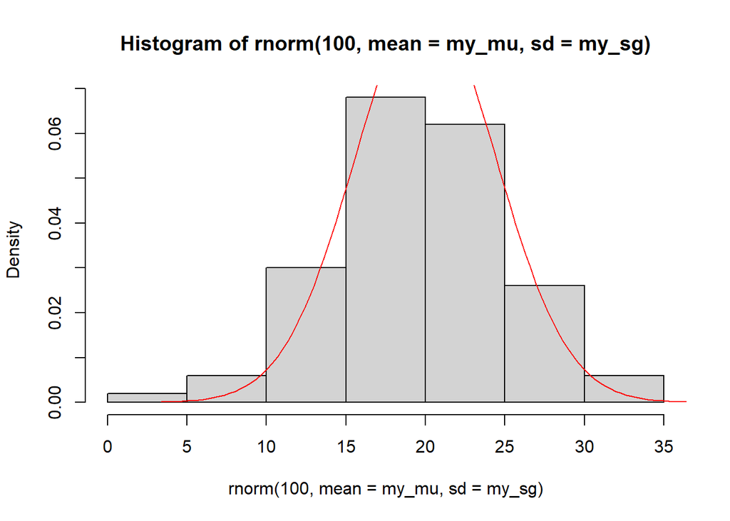

```r
hist(rnorm(100,mean=my_mu,sd=my_sg), freq=F)
curve(dnorm(x,mean=my_mu,sd=my_sg),from = xmin,to = xmax,ylab="densité",add=T,col="red")
```

With `ggplot2` use `geom.histogram()`:

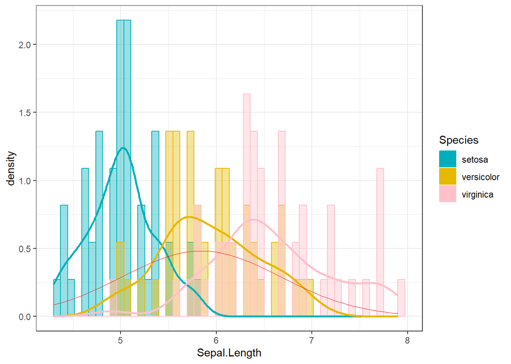

```r
#data <- data.frame(x = rnorm(100,mean=my_mu,sd=my_sg))
ggplot(iris, aes(x= Sepal.Length))+
  geom_histogram(aes (y=after_stat(density),color=Species, fill = Species), #after_stat(density) normalize to 1
                 bins = 50,
                 position = "identity",
                 alpha = 0.4,
                 )+ # bins number of interval un the histogram
  geom_density(aes(color = Species), linewidth = 1)+#show the density of each disribution
  stat_function(fun=dnorm,args=c(mean=mean(iris$Sepal.Length),sd=sd(iris$Sepal.Length)), #show the normal law theortic for the global distribution
                color ="red",
                linewidth = 0.1)+
  scale_color_manual(values = c("#00AFBB", "#E7B800","pink"))+ #use personalized color
  scale_fill_manual(values = c("#00AFBB", "#E7B800","pink"))+ #use personalized color
  theme_bw()
```

## The Box-plot

The boxplot can represent the distribution of the observation in function of the group. It gives also the quantile, the mean and the median information.

The easyiest way to have a boxplot is to use the basic R command: `boxplot(quantitative_variable~quatative_variable, labels)`. Between the quantitative_variable & the quantative_variable there is a (**~**).  
Example:

```r
boxplot(iris$Sepal.Length~iris$Species,ylab="Sepal Length",xlab="Species")
```

[output not shown]

With `ggplot2` use `geom.boxplot()`:

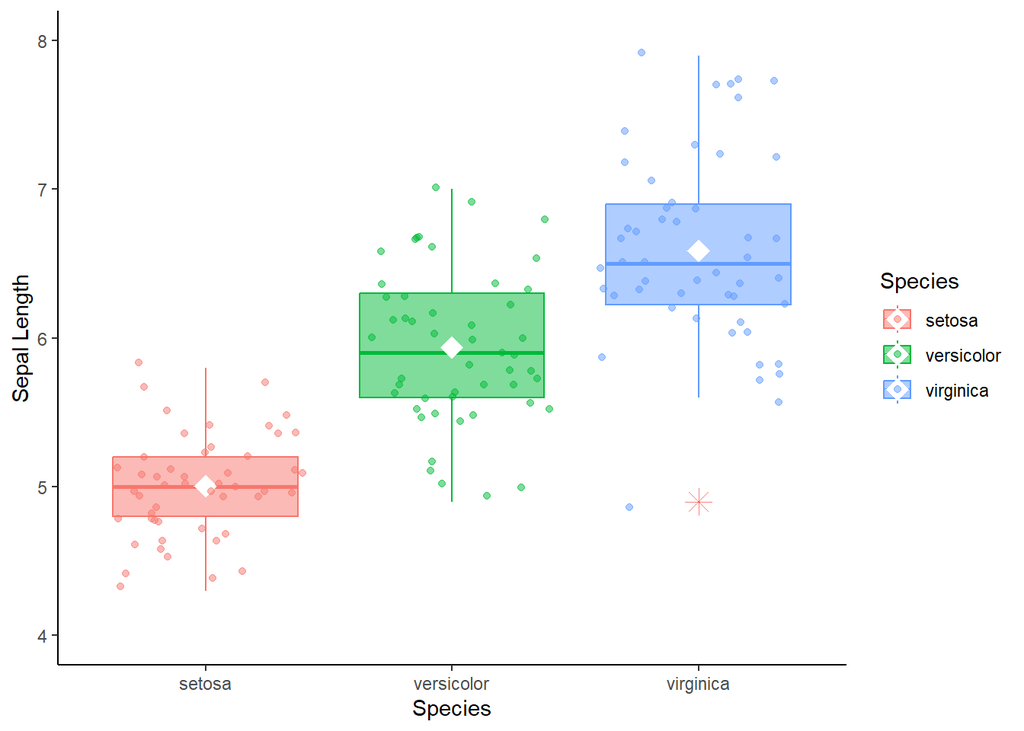

```r
p <- ggplot(iris, aes(x=Species, y=Sepal.Length, fill=Species, color = Species))+
  ylim(4,8)+
  ylab("Sepal Length")+
  geom_boxplot(alpha=0.5, # alpha for the transparence,
               outlier.colour="red",
               outlier.shape=8,outlier.size=4 # Note, outlier are shown twice
               #outlier.alpha=0 to not represent the outlier twices
               ) +
  stat_summary(fun = mean, geom="point", shape=18, size=5, color="white") +
  geom_point(position="jitter", alpha=.5)+
  theme_classic()
p
```

The function `stat_summary(fun.y = mean)` display the mean value.

## Multiple grahs

As it is showed, it is possible to combine several graphic in one by addition of `goem` functions. But sometimes, it is needed to separate the graphics. It is called the faceting. Two function can be used:

- `facet_warp(qualitative_variable, nrow = number of ligne)`
- `facet_grid(ligne ~column)`

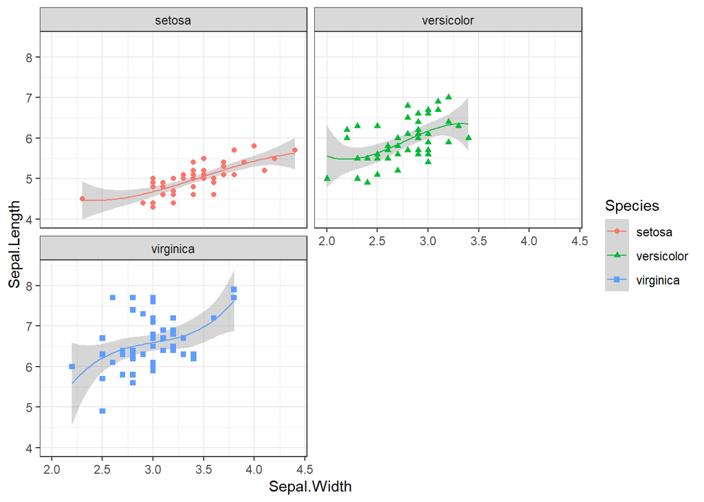

```r
ggplot(iris, aes(x=Sepal.Width, y=Sepal.Length, shape = Species, color=Species))+
  theme_bw()+
  geom_smooth(method="lm", formula= y~poly(x,3), se=TRUE, size = 0.5) +
  geom_point() +
  facet_wrap(iris$Species, nrow = 2)
```

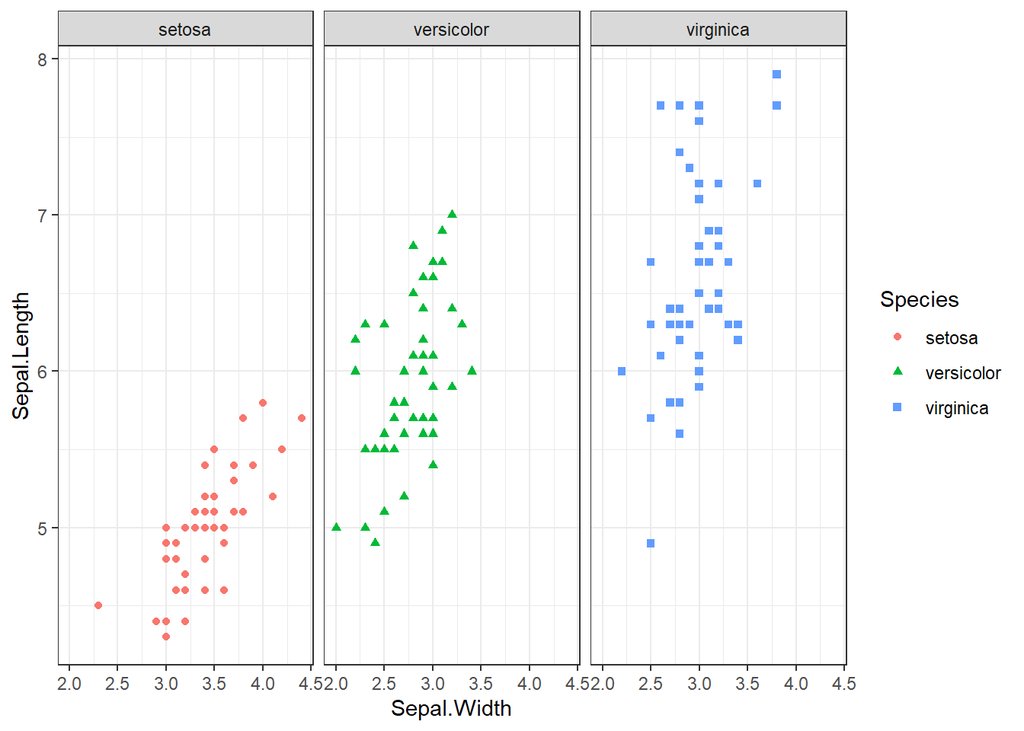

```r
ggplot(iris, aes(x=Sepal.Width, y=Sepal.Length, shape = Species, color = Species))+
  theme_bw()+
  geom_point() +
  facet_grid(~Species)
```

In the first facing graph, the function `geom_smooth(method="lm", formula= y\~poly(x,3), se=TRUE, size = 0.5)` has been introduced. This function is used to add a smooth regression curve to show the general trend of the dataset. Here the method used to draw this curve is a fitting linear model **lm.**

For more inspired graphs:  
https://rstudio-pubs-static.s3.amazonaws.com/578122_5e69256788bb4dcca6157d2bcfa7694e.html  
https://www.charlesbordet.com/fr/faire-beaux-graphiques-ggplot2/#it%C3%A9ration-4---ajouter-des-couleurs-pour-chaque-groupe

# Statistics Test

## Normality test

### Q-Q Plot

First we need to check if the distribution of the variable follow a normal law - which is the H0 hypothesis - is valid.

A rapid and graphical test is to check the Q-Q plot (droite d’henry):

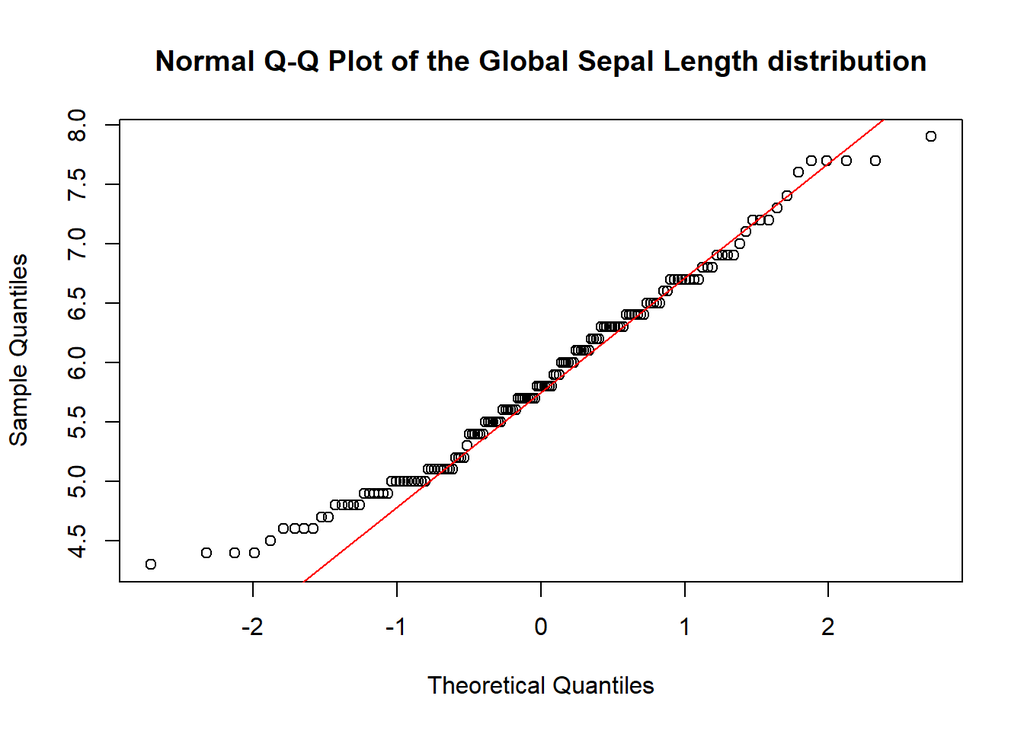

```r
qqnorm(iris$Sepal.Length, main = "Normal Q-Q Plot of the Global Sepal Length distribution")
qqline(iris$Sepal.Length, col="red")
```

Also with `ggplot`:

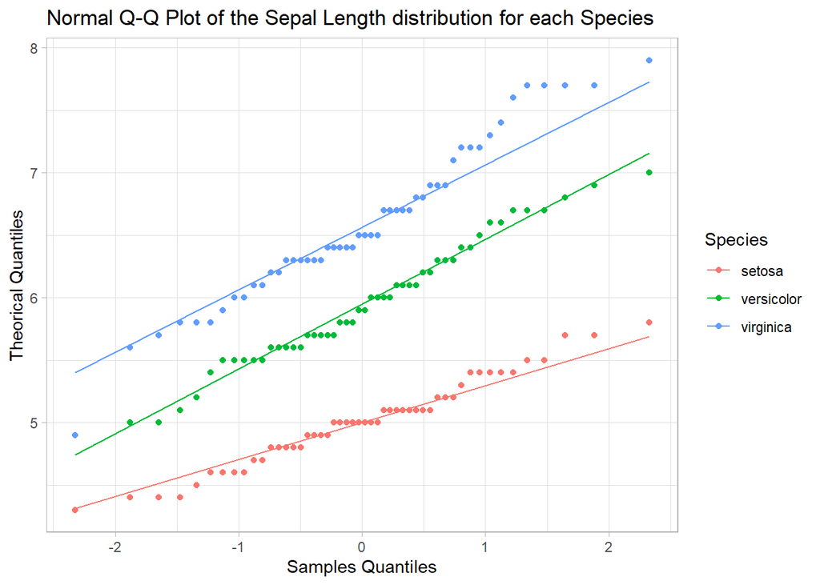

```r
ggplot(iris, aes(sample = Sepal.Length, colour = Species)) +
  stat_qq() +
  stat_qq_line()+
  theme_light()+
  xlab("Samples Quantiles")+
  ylab("Theorical Quantiles")+
  labs(title="Normal Q-Q Plot of the Sepal Length distribution for each Species")
```

The visual data analysis is not sufficient to proof the normality of the distribution. It is mandatory to complete by a statistical test in order to check the validation of the H0 hypothesis. If the test is significant (p-value < 0.05), the distribution is not normal. So the failure of the Significant test (p-value > 0.05) results on the normality of the distribution.

The normal test is sensitive to the sample length. Small effective usually pass the test. That why, both the visual inspection AND the normal test must to be performed.

*Remark:*  
*In reality, if the H0 hypothesis is NOT rejected, we can not affirm that the sample follow a normal law. Indeed, it is impossible to validate at 100% a theory because there are too many possibility. However, if the test is rejected in the given condition, this fact is certain*

### Shapiro-Wilk test

In R, this test is performed with the command `shapiro_test()` include in the `rstatix` package directly installed with the classic distribution of R.

*For One variable*

```r
library(rstatix)
shapiro_test(iris, Sepal.Length)
```

| variable | statistic | p |
| --- | --- | --- |
| Sepal.Length | 0.9760903 | 0.01018116 |

*Variables classify by group*

```r
iris %>%
  group_by(Species) %>%
  shapiro_test(Sepal.Length)
```

| Species | variable | statistic | p |
| --- | --- | --- | --- |
| setosa | Sepal.Length | 0.9776985 | 0.4595132 |
| versicolor | Sepal.Length | 0.9778357 | 0.4647370 |
| virginica | Sepal.Length | 0.9711794 | 0.2583147 |

Note, here the ``tidyverse`` library is use in order to manipulate the data

*For multiple variables*

```r
shapiro_test(iris, Sepal.Length, Petal.Width)
```

| variable | statistic | p |
| --- | --- | --- |
| Petal.Width | 0.9018349 | 1.680465e-08 |
| Sepal.Length | 0.9760903 | 1.018116e-02 |

Here the p-value of the Petal width is < 0.05 ==> Significant test ==> H0 rejected. The global distribution of the Petal width do not follow a normal law. This is can be checked by a simple Q-Q plot:

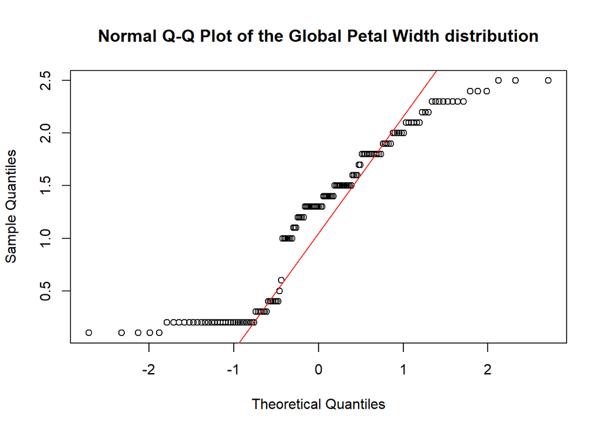

### Kolmogorov-Smirnov: an adequation test

Here the normality test is a particular case of the test.

In general this test enable to check the hypothesis that a sample follows of given CDF (normal, binary…) or if two samples follow a same law (normal, binary…).

*1) Creation of samples*

```r
a<-rnorm(100,mean=0,sd=1) # a normal law with 100 variables
b<-rgamma(100,shape=1,rate=0.8) # a other law
c<-rnorm(50,mean=0,sd=1) # the same normal law of a
d<-rnorm(50, mean=2, sd=1) # a second normal law but not with the same CDF
```

*2) Do a & b follow the same law ?*

```r
ks.test(a,b)
```

```
##
##  Asymptotic two-sample Kolmogorov-Smirnov test
##
## data:  a and b
## D = 0.46, p-value = 1.292e-09
## alternative hypothesis: two-sided
```

The p-value is very weak (<0.05) ==> Significant test ==> H0 rejected ==> The samples do not follow the same law

*2) Does a follow a normal law ?*

```r
ks.test(a,"pnorm") # Any normal law
```

```
##
##  Asymptotic one-sample Kolmogorov-Smirnov test
##
## data:  a
## D = 0.061094, p-value = 0.8495
## alternative hypothesis: two-sided
```

```r
ks.test(a,"pnorm",0,1) # A particular normal law define by a mean 0 & a sd 1
```

```
##
##  Asymptotic one-sample Kolmogorov-Smirnov test
##
## data:  a
## D = 0.061094, p-value = 0.8495
## alternative hypothesis: two-sided
```

```r
ks.test(a,"pnorm",2,1) # A particular normal law define by a mean 2 & a sd 1
```

```
##
##  Asymptotic one-sample Kolmogorov-Smirnov test
##
## data:  a
## D = 0.66391, p-value < 2.2e-16
## alternative hypothesis: two-sided
```

For the two first p-value > 0.05, the test is not significant ==> H0 validate . The last one, p-value < 0.05 ==> a does not follow this particular law.

*3) Do a, c & d follow the same normal law ?*

```r
ks.test(a,c)
```

```
##
##  Exact two-sample Kolmogorov-Smirnov test
##
## data:  a and c
## D = 0.15, p-value = 0.4298
## alternative hypothesis: two-sided
```

```r
ks.test(a,d)
```

```
##
##  Exact two-sample Kolmogorov-Smirnov test
##
## data:  a and d
## D = 0.64, p-value = 2.891e-13
## alternative hypothesis: two-sided
```

a & c follow the same normal law. Not d.

## The **Fisher** test: F-test

This test is performed to compare the equality of two variances. The H0 hypothesis is that $H_0:\sigma^{2}_{1}=\sigma^{2}_{2}$.

The F-test of fisher is given by the formula below (with $DF$ degree of freedom):
$$F =
\frac{\frac{\sigma_1^2}{DF_1}}{\frac{\sigma_2^2}{DF_2}}$$

```r
setosa <- subset(iris, Species == "setosa")
virginica <- subset(iris, Species == "virginica")
versicolor <- subset(iris, Species == "versicolor")
var.test(setosa$Sepal.Width, virginica$Sepal.Width,conf.level = 0.95) # with a bilateral risk of 5%
```

```
##
##  F test to compare two variances
##
## data:  setosa$Sepal.Width and virginica$Sepal.Width
## F = 1.3816, num df = 49, denom df = 49, p-value = 0.2614
## alternative hypothesis: true ratio of variances is not equal to 1
## 95 percent confidence interval:
##  0.7840128 2.4346017
## sample estimates:
## ratio of variances
##           1.381578
```

Here the p-value is superior to 0.05: H0 is not rejected.

```r
var.test(virginica$Sepal.Length, virginica$Sepal.Width,conf.level = 0.95) # with a bilateral risk of 5%
```

```
##
##  F test to compare two variances
##
## data:  virginica$Sepal.Length and virginica$Sepal.Width
## F = 3.8878, num df = 49, denom df = 49, p-value = 5.014e-06
## alternative hypothesis: true ratio of variances is not equal to 1
## 95 percent confidence interval:
##  2.206211 6.850965
## sample estimates:
## ratio of variances
##            3.88776
```

Here the p-value is largely under 0.05. The H0 hypothesis is rejected, that mean that the variance between this two categories are different.

**WARNING**:  
This test should not be confused with Fisher’s exact test or the Fisher test for the independence, which is performed to compare the dependence of several groups:

- The exact test of Fisher is used for sa contingent tables cf. $\chi^{2}$ test
- The F-test of variance compare the variance of two different groups individual
- The F-test of independence use also the variance but compare one group with all the other group cf. ANOVA

## Comparison of the mean

### The **Student** test: t-test

This test is performed to compare the equality of two means. The H0 hypothesis is that $H_0:µ_{1}=µ_{2}$. In other words, are the populations from which the samples were taken the same?.

This test need 3 conditions:

1. n > 8
2. The samples must to follow the normal law (shapiro_test)
3. The variances must to be equal (F-test) ==> Use the argument `var.equal = TRUE`

Then we can performed the t test.

```r
t.test(setosa$Sepal.Width, virginica$Sepal.Width,conf.level = 0.95, var.equal = TRUE)
```

```
##
##  Two Sample t-test
##
## data:  setosa$Sepal.Width and virginica$Sepal.Width
## t = 6.4503, df = 98, p-value = 4.246e-09
## alternative hypothesis: true difference in means is not equal to 0
## 95 percent confidence interval:
##  0.3143257 0.5936743
## sample estimates:
## mean of x mean of y
##     3.428     2.974
```

Here the p-value is largely under 0.05. The H0 hypothesis is rejected, that mean that the means of this two categories are different.

If the variances between the two is not equal ==> Use the **Welch approximation** with `var.equal = FALSE`

```r
t.test(virginica$Sepal.Length, virginica$Sepal.Width, conf.level = 0.95, var.equal = FALSE)
```

```
##
##  Welch Two Sample t-test
##
## data:  virginica$Sepal.Length and virginica$Sepal.Width
## t = 35.842, df = 72.643, p-value < 2.2e-16
## alternative hypothesis: true difference in means is not equal to 0
## 95 percent confidence interval:
##  3.413027 3.814973
## sample estimates:
## mean of x mean of y
##     6.588     2.974
```

### The **Wilcoxon** test

When the distribution doesn’t follow a normal law, or if n < 8, it is possible to use the Wilcoxon test:

```r
wilcox.test(iris$Petal.Length, iris$Petal.Width, conf.level = 0.95)
```

```
##
##  Wilcoxon rank sum test with continuity correction
##
## data:  iris$Petal.Length and iris$Petal.Width
## W = 19349, p-value < 2.2e-16
## alternative hypothesis: true location shift is not equal to 0
```

*Note that the Wilcoxon test does not give the resultats over the mean but by ranking the variables*

# Detection of Outliers

Outlier can be detected with barplot. However, it can be performed with a statistical test. In R, the detection of outliers is performed thanks to library `outliers`.

## Dixon test: Q-test

The Dixon test can be used for the small samples and evaluate the outliers by comparison of distances a between a suspect point and the measurement nearest to it in size with the range of the measurements. Thus, the H0 hypothesis is: the value is not an outlier.

[output not shown]

The Dixon test is performed one by one, that means if there are 2 or more variables, the test must be performed until that the p-value is higher than 0.05.

```r
# dataset
data_for_dixon <- c(-1000, 10, 12, 13, 14, 15, 16, 17, 18, 19,200.5)

# initialization of pvalue to enter into the loop
pvalue <- 0

# loop while until the p-value is > 0.05
while(pvalue < 0.05){
  #test
  result_dixon <- dixon.test(data_for_dixon)
  pvalue <- result_dixon$p.value # catch the p-value in variable

  # if pvalue is under 0.05 ==> remove the outlier
  if (pvalue <0.05){
    # catch the outlier in variable:
    #     $alternative is a chain of character
    #     Split into a list and select the 3erd word
    #     Convert into a numeric value
    val_outlier <- as.numeric(strsplit(result_dixon$alternative, " ")[[1]][3])

    # Remove the outlier
    data_for_dixon <- data_for_dixon[-which(data_for_dixon==val_outlier)]
  }
  # Printing
  print(result_dixon)
  print(data_for_dixon)
}
```

```
##
##  Dixon test for outliers
##
## data:  data_for_dixon
## Q = 0.99313, p-value < 2.2e-16
## alternative hypothesis: lowest value -1000 is an outlier
##
##  [1]  10.0  12.0  13.0  14.0  15.0  16.0  17.0  18.0  19.0 200.5
##
##  Dixon test for outliers
##
## data:  data_for_dixon
## Q = 0.96286, p-value < 2.2e-16
## alternative hypothesis: highest value 200.5 is an outlier
##
## [1] 10 12 13 14 15 16 17 18 19
##
##  Dixon test for outliers
##
## data:  data_for_dixon
## Q = 0.25, p-value = 0.7435
## alternative hypothesis: lowest value 10 is an outlier
##
## [1] 10 12 13 14 15 16 17 18 19
```

## The Grubbs test

When the dataset has more than 30 values, the Dixon test does not work:

```r
  dixon.test(versicolor$Sepal.Length)
```

```
## Une erreur s'est produite : Sample size must be in range 3-30
```

In this case, the Grubbs test is more useful. The test is also performed one by one. So to remove all the outliers, we need to process by iteration like the Dixon test before.

```r
grubbs.test(versicolor$Sepal.Length)
```

```
##
##  Grubbs test for one outlier
##
## data:  versicolor$Sepal.Length
## G = 2.06133, U = 0.91151, p-value = 0.8977
## alternative hypothesis: highest value 7 is an outlier
```

```r
grubbs.test(virginica$Sepal.Length)
```

```
##
##  Grubbs test for one outlier
##
## data:  virginica$Sepal.Length
## G = 2.65459, U = 0.85325, p-value = 0.1509
## alternative hypothesis: lowest value 4.9 is an outlier
```

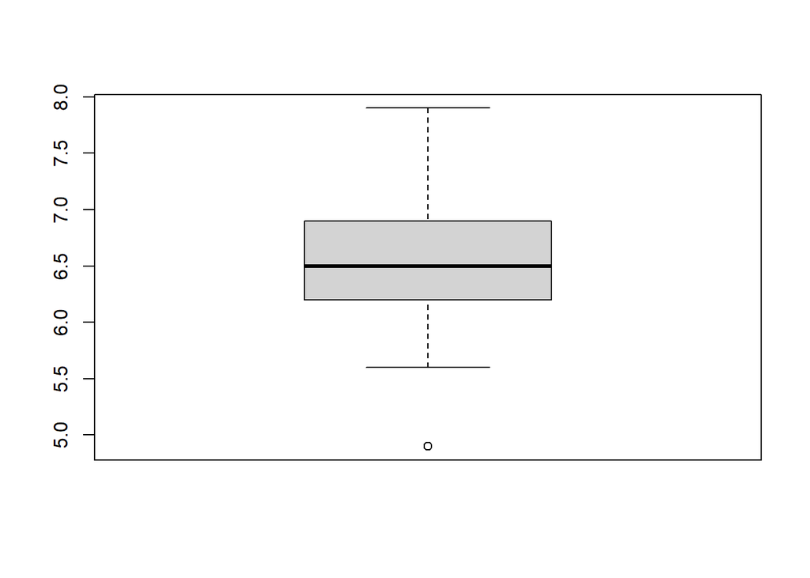

```r
boxplot(virginica$Sepal.Length)
```

*Remark: Here the Grubbs test does not find outlier, whereas the box plot yes. In fact outlier in boxplot are not performed by a true statistical test. That’s why, in case of doulbt, it is mandatory to performe a test.*

# ANOVA

**The analysis of variance**. The purpose of this test is to find which factor has an impact on the variance. This analysis is based on the test of Fisher. This is closed to the F-test of variance. Except that the comparison is not performed on two individual groups but compare the variance between all the group over the variance inside one group:

$$F =
\frac{\frac{\sigma_{inter}^2}{DF_{inter}}}{\frac{\sigma_{intra}^2}{DF_{intra}}}$$

With $\sigma_{inter}^2$ the variance inter (betwenn) group: $\sigma_{inter}^2=\sum(mean_{group}-mean_{total})^2$  
And $\sigma_{intra}^2$ the variance in a particular group $\sigma_{intra}^2=\sum(x_{i}-\overline{x_{group}})^2$

ANOVA assumes that the observations are independent, follow a normal law and there is no significant outlier. The H0 hypothesis:

- H0: Groups are independent ==> No effect of the factor <=> means are equal
- H1: Groups are not independent ==> Significant effect <=> means not are equal

## One-way ANOVA

ANOVA, in R, is performed thanks to the command `aov(observation~factor, dataset)`. The results can be shown thanks to the command `summary.aov`.

```r
species_anova <- aov(Sepal.Length~Species, iris)
summary.aov(species_anova)
```

```
##              Df Sum Sq Mean Sq F value Pr(>F)
## Species       2  63.21  31.606   119.3 <2e-16 ***
## Residuals   147  38.96   0.265
## ---
## Signif. codes:  0 '***' 0.001 '**' 0.01 '*' 0.05 '.' 0.1 ' ' 1
```

Here the p-value is under 0.05. That means that the H0 is rejected. The factor Species has significant impact on the Sepal length.

## Two-way ANOVA

For this example, the dataset `ToothGrowth` is used, and it is assume that all the condition for the ANOVA are OK. This dataset examines the tooth growth length in guinea pigs based on the dosage and supplementation of vitamin C.

The two-way ANOVA, in R, is performed with the same command than the one-way. The interaction between the two factors are add with the symbol `*` between the 2 factors: `aov(observation~factor1*factor2, dataset)`.

```r
summary(ToothGrowth)
```

```
##       len        supp         dose
##  Min.   : 4.20   OJ:30   Min.   :0.500
##  1st Qu.:13.07   VC:30   1st Qu.:0.500
##  Median :19.25           Median :1.000
##  Mean   :18.81           Mean   :1.167
##  3rd Qu.:25.27           3rd Qu.:2.000
##  Max.   :33.90           Max.   :2.000
```

```r
ToothGrowth$dose <- as.factor(ToothGrowth$dose) # dose is numeric ==> Conversion as a factor
summary(ToothGrowth)
```

```
##       len        supp     dose
##  Min.   : 4.20   OJ:30   0.5:20
##  1st Qu.:13.07   VC:30   1  :20
##  Median :19.25           2  :20
##  Mean   :18.81
##  3rd Qu.:25.27
##  Max.   :33.90
```

```r
# 2-way ANOVA
tooth_anova <- aov(len~supp*dose,ToothGrowth)
summary.aov(tooth_anova)
```

```
##             Df Sum Sq Mean Sq F value   Pr(>F)
## supp         1  205.4   205.4  15.572 0.000231 ***
## dose         2 2426.4  1213.2  92.000  < 2e-16 ***
## supp:dose    2  108.3    54.2   4.107 0.021860 *
## Residuals   54  712.1    13.2
## ---
## Signif. codes:  0 '***' 0.001 '**' 0.01 '*' 0.05 '.' 0.1 ' ' 1
```

Here the p-value is under 0.05 for both spplementation and the dosage of vitamin C. That means that the H0 is rejected. This two factors have a significant impact. In the same time, the impact of the interaction between this two factor is also significant (p-value <0.05).

### Graph analysis of the ToothGrowth with ggarrange()

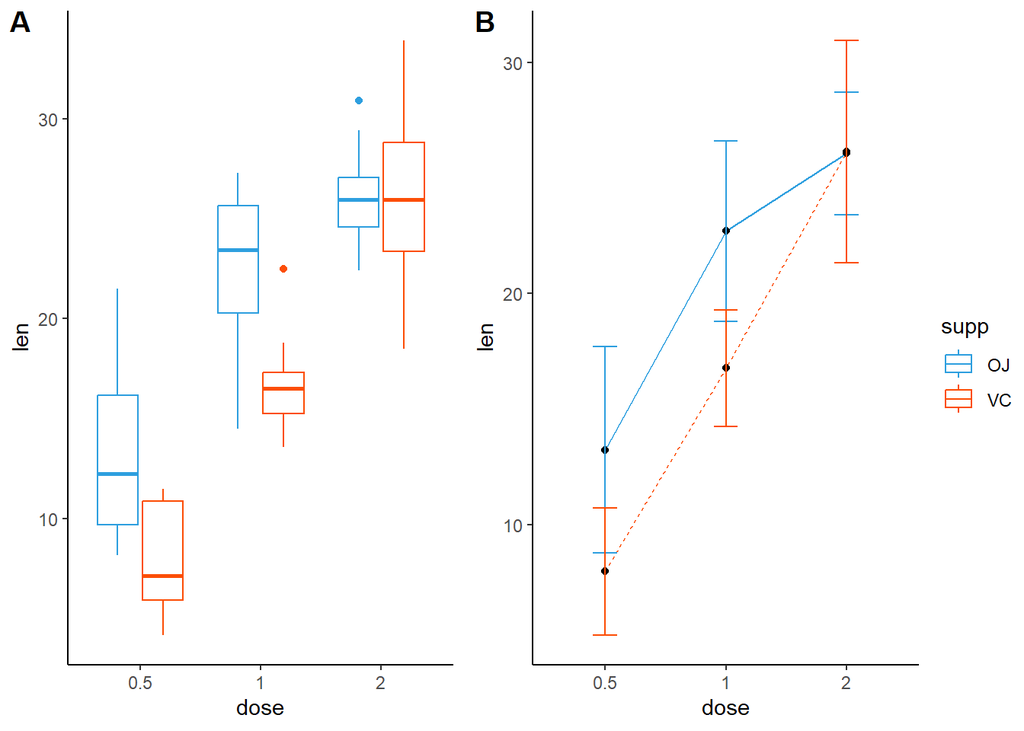

```r
# Setp 1 cheration of the theme
theme_set(
  theme_classic() +
    theme(legend.position = "top")
  )
my3cols <- c("#2E9FDF", "#FC4E07", "#E7B800")

# Prepar
ToothGrowth$dose <- as.factor(ToothGrowth$dose)
df.summary <- ToothGrowth %>%
  group_by(dose,supp) %>%
  summarise(sd = sd(len, na.rm = TRUE), len = mean(len))

# Step 2 Creation of the different graphs

# 1- The box plot
bxp <- ggplot(ToothGrowth, aes(x = dose, y = len))+ geom_boxplot(aes(color = supp)) +
  scale_color_manual(values = my3cols)

# 3- line plot
lin <- ggplot(df.summary, aes(dose, len)) +
  geom_line(aes(linetype = supp, group = supp, color=supp))+
  geom_point()+
  geom_errorbar(
    aes(ymin = len-sd, ymax = len+sd, group = supp, color=supp),
    width = 0.2
  )+
  scale_color_manual(values = my3cols)

# STeo 3 pool the graphs together

library("ggpubr")
figure <- ggarrange(bxp, lin,
                    labels = c("A", "B"),
                    ncol = 2, nrow = 1,
                    common.legend = TRUE,
                    legend = "right")
figure
```

# Princpal Composante Analysis (PCA)

The PCA is a unsupervised analysis which is used to reduce the number of the variables. Indeed, with more than 3 observation, it’s become complicated to represent graphically the information, thus the goal of the PCA is to reduce the number of dimension in order to have a better visualization.

Two packages are recommended to used (developed by french people):  
- `FactoMineR` -> For the statistical methods - `factoextra` -> For the visualization

```r
library("FactoMineR")
library("factoextra")
library("ggpubr")
```

To work on the PCA, the dataset `decathlon` is used (created to this purpose).

```r
decathlon<-read.table("https://r-stat-sc-donnees.github.io/decathlon.csv",
                      header=TRUE,sep=";",dec=".",
                      row.names=1,check.names=FALSE,fileEncoding="latin1")
head(decathlon)
```

|  | 100m | Longueur | Poids | Hauteur | 400m | 110m H | Disque | Perche | Javelot | 1500m | Classement | Points | Competition |
| --- | --- | --- | --- | --- | --- | --- | --- | --- | --- | --- | --- | --- | --- |
| Sebrle | 10.85 | 7.84 | 16.36 | 2.12 | 48.36 | 14.05 | 48.72 | 5.0 | 70.52 | 280.01 | 1 | 8893 | JO |
| Clay | 10.44 | 7.96 | 15.23 | 2.06 | 49.19 | 14.13 | 50.11 | 4.9 | 69.71 | 282.00 | 2 | 8820 | JO |
| Karpov | 10.50 | 7.81 | 15.93 | 2.09 | 46.81 | 13.97 | 51.65 | 4.6 | 55.54 | 278.11 | 3 | 8725 | JO |
| Macey | 10.89 | 7.47 | 15.73 | 2.15 | 48.97 | 14.56 | 48.34 | 4.4 | 58.46 | 265.42 | 4 | 8414 | JO |
| Warners | 10.62 | 7.74 | 14.48 | 1.97 | 47.97 | 14.01 | 43.73 | 4.9 | 55.39 | 278.05 | 5 | 8343 | JO |
| Zsivoczky | 10.91 | 7.14 | 15.31 | 2.12 | 49.40 | 14.95 | 45.62 | 4.7 | 63.45 | 269.54 | 6 | 8287 | JO |

## PCA of individue

```r
# Make the PCA
pca.decat <- PCA(decathlon[,-c(11:13)], graph=FALSE) # keep only the variables of interest
```

Then make the graph with `fviz_pca_ind`

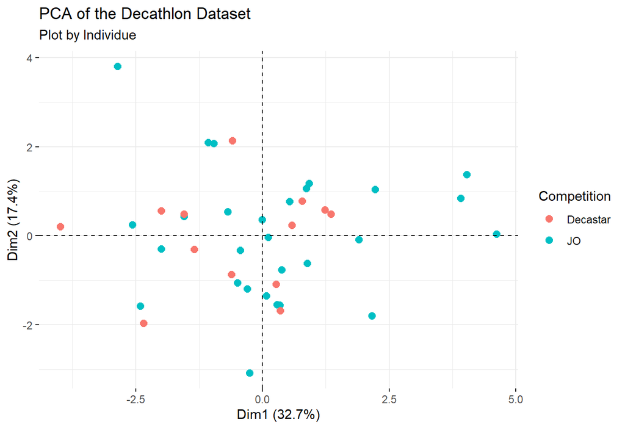

```r
graph1 <- fviz_pca_ind(pca.decat, axes = c(1,2), #plot with the dimension selected
                       pointshape = 20,
                       pointsize = 4,
                       geom.ind = "point",
                       mean.point = F, #hide the point of the mean
                       col.ind = decathlon$Competition,
                       addEllipses = FALSE)
ggpar(graph1, title = "PCA of the Decathlon Dataset",
      subtitle = expression(paste("Plot by Individue", sep = "")), #expression(paste) => permet de mettren en indice [] ou exposant ^
      caption = "",
      legend = "right",
      legend.title = "Competition")
```

It could be interesting to see the sree plot

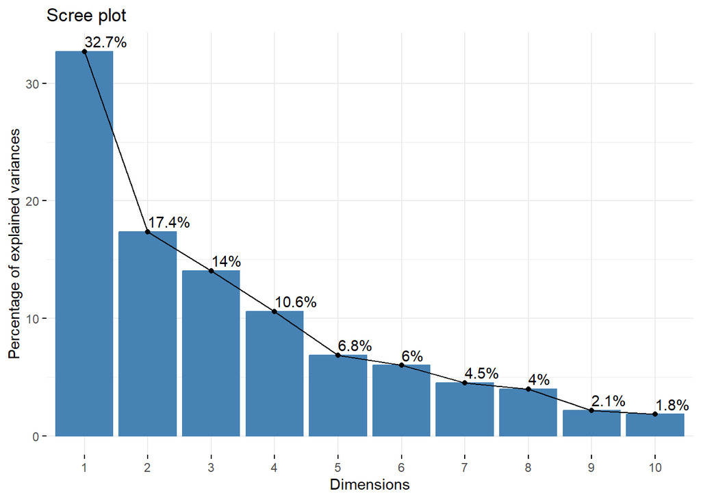

```r
# Scree plot
fviz_eig(pca.decat, addlabels =TRUE)
```

3D plot

```r
library("rgl")
#  3 D dans R
plot3d(pca.decat$ind$coord[,1],
       pca.decat$ind$coord[,2],
       pca.decat$ind$coord[,3],
       xlab="Dim1",ylab="Dim2",zlab="Dim3")
```

*Remark a new windows will appears.*  
With the code below and a GIMP software, it is possible to create an animation of the 3D picture.

```r
setwd("C:/Users/hpier/Documents/code/R/ChemoinfoR_tuto")
for (i in 1:360) {
  par3d(i, 20) ;
  filename <- paste("pic", formatC(i, digits = 1, flag = "0"), ".png", sep = "")
  rgl.snapshot(filename) } ;
  getwd()
```

# Linear Regression

## Creation of the Linear model

A linear regression $y=f(x)$ can be implemented thanks to the following function: `lm(y~x, data=my_dataset)`. It is based on the least square method.  
To force the curve to trough the origin, it just needed to add the value `-1`after the x data.

```r
my_model <- lm(data=iris, Sepal.Length~Sepal.Width)
summary(my_model)
```

```
##
## Call:
## lm(formula = Sepal.Length ~ Sepal.Width, data = iris)
##
## Residuals:
##     Min      1Q  Median      3Q     Max
## -1.5561 -0.6333 -0.1120  0.5579  2.2226
##
## Coefficients:
##             Estimate Std. Error t value Pr(>|t|)
## (Intercept)   6.5262     0.4789   13.63   <2e-16 ***
## Sepal.Width  -0.2234     0.1551   -1.44    0.152
## ---
## Signif. codes:  0 '***' 0.001 '**' 0.01 '*' 0.05 '.' 0.1 ' ' 1
##
## Residual standard error: 0.8251 on 148 degrees of freedom
## Multiple R-squared:  0.01382,    Adjusted R-squared:  0.007159
## F-statistic: 2.074 on 1 and 148 DF,  p-value: 0.1519
```

```r
# Force trough to the origin
my_model0 <- lm(Sepal.Length~Sepal.Width-1, data=iris)
summary(my_model0)
```

```
##
## Call:
## lm(formula = Sepal.Length ~ Sepal.Width - 1, data = iris)
##
## Residuals:
##     Min      1Q  Median      3Q     Max
## -2.5236 -1.0362  0.4823  0.9897  2.8406
##
## Coefficients:
##             Estimate Std. Error t value Pr(>|t|)
## Sepal.Width  1.86901    0.03265   57.25   <2e-16 ***
## ---
## Signif. codes:  0 '***' 0.001 '**' 0.01 '*' 0.05 '.' 0.1 ' ' 1
##
## Residual standard error: 1.235 on 149 degrees of freedom
## Multiple R-squared:  0.9565, Adjusted R-squared:  0.9562
## F-statistic:  3277 on 1 and 149 DF,  p-value: < 2.2e-16
```

t value = estimate / standard error => must be high `Pr(>|t|)` => Probability to have the real value is upper the t value => must be small.  
Again we can look at the p-value.  
In this case the my_model0 is better than my_model1.

## Exploitation of the model

### Graph

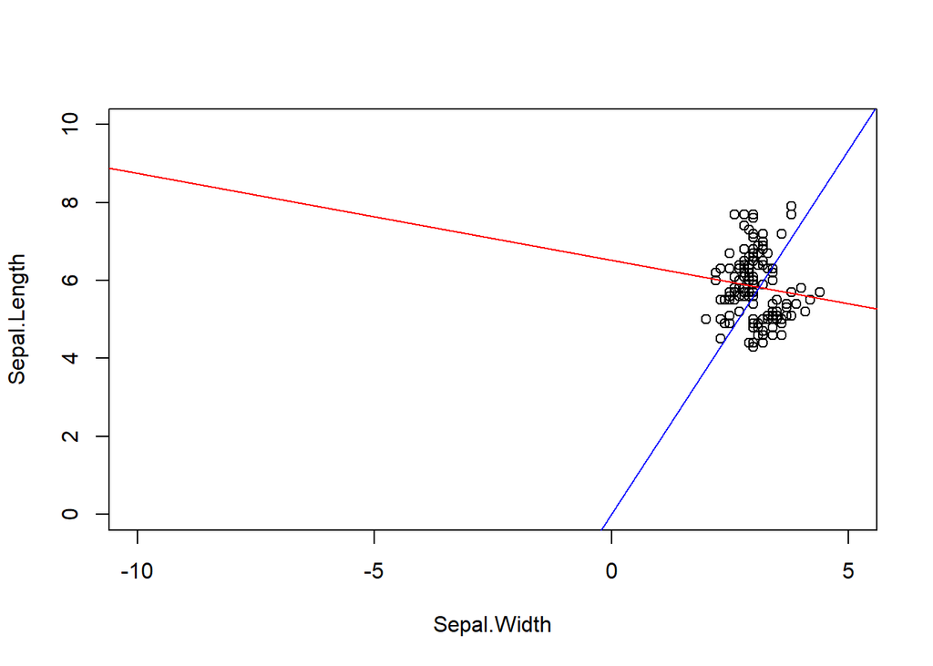

```r
plot(Sepal.Length~Sepal.Width, data = iris, xlim=c(-10,5), ylim=c(0,10))
abline(my_model, col="red")
abline(my_model0, col="blue")
```

### Statisitcal analysis of the model

```r
# Catch the stats of the model in a variable
Stat_myModel<-summary(my_model)

# Catch the interception (b) and the standard error
interception <- Stat_myModel[["coefficients"]][1,1]
error_std <- Stat_myModel[["coefficients"]][1,2]

# Analysis of the confidence interval
t95<-qt(0.975,2) # Student's bilateral quantile at 5% risk
ICmin_int<-interception - t95 * error_std # lower bound of IC(95) of intercept
ICmax_int<-interception + t95 * error_std # upper bound of IC(95) of intercept

# Print results
print(paste("Interception =",signif(interception,3), "in the interval of [",signif(ICmin_int,3),";",signif(ICmax_int,3),"]."))
```

```
## [1] "Interception = 6.53 in the interval of [ 4.47 ; 8.59 ]."
```

### Prediction

To predict new $Y$ from new value $x$

```r
p1 <- predict.lm(my_model, tibble("Sepal.Width"=c(2.7)))
p0 <- predict.lm(my_model0, tibble("Sepal.Width"=c(2.7)))

print(paste("Model 1: Y_pred =", signif(p1,3),
            " | Model 2 (trough 0); Y_pred =",signif(p0,3)))
```

```
## [1] "Model 1: Y_pred = 5.92  | Model 2 (trough 0); Y_pred = 5.05"
```

To predict new $x$ from $Y$, is not possible to do it directly with `predict.lm`. Calculate x from the coefficient following this equation: $Y=ax+b <=> x=\frac{Y-b}{a}$

```r
coef_model <- coef(my_model)
coef_model0 <- coef(my_model0)

Y_new <- 8.3
x_pred_1 <- (Y_new-coef_model[1])/coef_model[2]
x_pred_2 <- (Y_new)/coef_model0[1]

print(paste("Model 1: x_pred =", signif(x_pred_1,3),
            " | Model 2 (trough 0); x_pred =",signif(x_pred_2,3)))
```

```
## [1] "Model 1: x_pred = -7.94  | Model 2 (trough 0); x_pred = 4.44"
```